# FRE9733Homework7_DenizKural

## K-Means and Hierarchical Clustering & Association Rules

#### FRE 9733 - Homework 7

#### Deniz Kural - dk3703

### K - means Clustering and Hierarchical Clustering with Mocked Customer Data

```python
#Step 1 - Import all the libraries
import pandas as pd
import matplotlib.pyplot as plt
import numpy as np
from sklearn import model_selection
from sklearn.model_selection import cross_val_score
from sklearn.model_selection import KFold
import seaborn as sn
from sklearn.preprocessing import LabelEncoder
from sklearn.model_selection import train_test_split
from sklearn.preprocessing import StandardScaler
from sklearn.cluster import KMeans
import warnings
warnings.filterwarnings('ignore')
import matplotlib.cm as cm
import scipy.cluster.hierarchy as shc
from sklearn.cluster import AgglomerativeClustering
from mlxtend.frequent_patterns import apriori
from mlxtend.frequent_patterns import association_rules

%matplotlib inline
```

```python
#Import the dataset
df= pd.read_excel(r"C:\Users\deniz\Dropbox\My PC (Duygu)\Desktop\BigdataHW7\Mocked_Customer_Data.xlsx")
```

```python
df.head()
```

|  | cust_id | gender | marrital | age | home_owner | num_cont | tot_bill | tot_call | tot_bal | fortune | tot_bytes | tot_air | num_out | google_bytes | google_air | yahoo_bytes | yahoo_air |
| --- | --- | --- | --- | --- | --- | --- | --- | --- | --- | --- | --- | --- | --- | --- | --- | --- | --- |
| 0 | c000001 | Male | divorced | 49 | 0 | 0 | 134.130817 | 53 | 4973.07 | Mass | 931.28 | 3046.90 | 194 | 320.52 | 1270.23 | 194.04 | 710.45 |
| 1 | c000002 | Male | divorced | 33 | 0 | 1 | 121.247165 | 68 | 4528.01 | LMI | 580.62 | 3549.74 | 331 | 491.50 | 1484.64 | 32.14 | 823.42 |
| 2 | c000003 | Female | divorced | 38 | 0 | 1 | 164.144198 | 38 | 5565.09 | Affluent | 754.07 | 2996.59 | 139 | 283.24 | 764.69 | 182.07 | 718.69 |
| 3 | c000004 | Female | married | 26 | 1 | 1 | 177.394137 | 80 | 5370.00 | Affluent | 384.81 | 2443.78 | 98 | 384.81 | 721.44 | 145.09 | 742.61 |
| 4 | c000005 | Male | single | 55 | 0 | 2 | 155.183919 | 50 | 5101.25 | Affluent | 15.30 | 2576.98 | 294 | 15.30 | 774.92 | 15.30 | 710.88 |

```python
#Step 2
#Data Quality and Completeness

df.columns
```

```
Index(['cust_id', 'gender', 'marrital', 'age', 'home_owner', 'num_cont',
       'tot_bill', 'tot_call', 'tot_bal', 'fortune', 'tot_bytes', 'tot_air',
       'num_out', 'google_bytes', 'google_air', 'yahoo_bytes', 'yahoo_air'],
      dtype='object')
```

```python
df.describe()
```

|  | age | home_owner | num_cont | tot_bill | tot_call | tot_bal | tot_bytes | tot_air | num_out | google_bytes | google_air | yahoo_bytes | yahoo_air |
| --- | --- | --- | --- | --- | --- | --- | --- | --- | --- | --- | --- | --- | --- |
| count | 40000.000000 | 40000.000000 | 40000.000000 | 40000.000000 | 40000.000000 | 40000.000000 | 40000.000000 | 40000.000000 | 40000.000000 | 40000.000000 | 40000.000000 | 40000.000000 | 40000.000000 |
| mean | 44.528625 | 0.600000 | 1.998875 | 124.986534 | 74.549700 | 5496.517940 | 1504.349711 | 2896.281553 | 153.802650 | 319.444523 | 901.499544 | 222.769098 | 675.602853 |
| std | 11.093589 | 0.489904 | 0.773621 | 35.689399 | 35.646982 | 742.751898 | 696.499597 | 510.388510 | 103.381545 | 107.447809 | 222.361519 | 101.929949 | 159.983881 |
| min | -1.000000 | 0.000000 | 0.000000 | 0.000000 | 0.000000 | 2648.750000 | 0.330000 | 751.380000 | 0.000000 | 0.330000 | 27.130000 | 0.090000 | 161.970000 |
| 25% | 37.000000 | 0.000000 | 1.000000 | 99.220353 | 47.000000 | 4947.027500 | 977.340000 | 2554.792500 | 73.000000 | 249.170000 | 749.750000 | 151.130000 | 548.985000 |
| 50% | 45.000000 | 1.000000 | 2.000000 | 129.915934 | 70.000000 | 5453.905000 | 1502.130000 | 2891.220000 | 150.000000 | 321.185000 | 901.640000 | 221.905000 | 676.335000 |
| 75% | 52.000000 | 1.000000 | 3.000000 | 152.212860 | 100.000000 | 6023.875000 | 2024.902500 | 3239.507500 | 226.000000 | 391.730000 | 1053.460000 | 291.952500 | 801.922500 |
| max | 87.000000 | 1.000000 | 5.000000 | 235.785533 | 219.000000 | 8158.480000 | 3827.720000 | 4977.580000 | 588.000000 | 759.000000 | 1794.100000 | 648.700000 | 1207.910000 |

```python
#Display data types of the dataset
df.dtypes
```

```
cust_id          object
gender           object
marrital         object
age               int64
home_owner        int64
num_cont          int64
tot_bill        float64
tot_call          int64
tot_bal         float64
fortune          object
tot_bytes       float64
tot_air         float64
num_out           int64
google_bytes    float64
google_air      float64
yahoo_bytes     float64
yahoo_air       float64
dtype: object
```

```python
#Display the categorical vs. numerical variables
df.columns.to_series().groupby(df.dtypes).groups
```

```
{int64: ['age', 'home_owner', 'num_cont', 'tot_call', 'num_out'], float64: ['tot_bill', 'tot_bal', 'tot_bytes', 'tot_air', 'google_bytes', 'google_air', 'yahoo_bytes', 'yahoo_air'], object: ['cust_id', 'gender', 'marrital', 'fortune']}
```

##### Object variables should be handled before processing into model built and evaluation stage.These are:

**object**: ['cust_id', 'gender', 'marrital', 'fortune']

```python
#Data Completeness
#Get the info. for both missing values in each column and also type of variables in each column
df.info()
```

```
<class 'pandas.core.frame.DataFrame'>
RangeIndex: 40000 entries, 0 to 39999
Data columns (total 17 columns):
 #   Column        Non-Null Count  Dtype
---  ------        --------------  -----
 0   cust_id       40000 non-null  object
 1   gender        40000 non-null  object
 2   marrital      40000 non-null  object
 3   age           40000 non-null  int64
 4   home_owner    40000 non-null  int64
 5   num_cont      40000 non-null  int64
 6   tot_bill      40000 non-null  float64
 7   tot_call      40000 non-null  int64
 8   tot_bal       40000 non-null  float64
 9   fortune       40000 non-null  object
 10  tot_bytes     40000 non-null  float64
 11  tot_air       40000 non-null  float64
 12  num_out       40000 non-null  int64
 13  google_bytes  40000 non-null  float64
 14  google_air    40000 non-null  float64
 15  yahoo_bytes   40000 non-null  float64
 16  yahoo_air     40000 non-null  float64
dtypes: float64(8), int64(5), object(4)
memory usage: 5.2+ MB
```

```python
#Display the columns with missing variables if any
df.isna().any()
```

```
cust_id         False
gender          False
marrital        False
age             False
home_owner      False
num_cont        False
tot_bill        False
tot_call        False
tot_bal         False
fortune         False
tot_bytes       False
tot_air         False
num_out         False
google_bytes    False
google_air      False
yahoo_bytes     False
yahoo_air       False
dtype: bool
```

So, it seems that we do not have any missing value in our dataset. So, there is no need for imputation methods to deal with missing data which is a crucial issue for K means clustering

This dataset is mainly for understanding the churn rate of customer. We do not need labeling for churns in clustering methods, so we only need to understand features of our dataset in order to understand the resultant cluster of points.

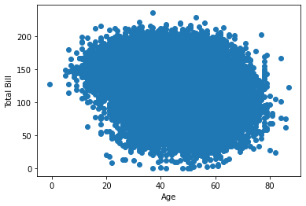

```python
#We can give an example of visualization of two features in plot.
#But we will cluster all of the features in a higher dimension
X = df[["age","tot_bill"]]
#Visualise data points
plt.scatter(X["age"],X["tot_bill"])
plt.xlabel('Age')
plt.ylabel('Total Bill')
plt.show()
```

As can be observed, there is a dense distribution of points in the resultant scatter plot for two selected features.

```python
#Create label encoder for feature with less than or equal to 2  unique values
#In our case, this will be only gender column with 2 unique values ['male','female']

#Create a label encoder object
le = LabelEncoder()
# Label Encoding will be used for columns with 2 or less unique values
le_count = 0

for col in df.columns[1:]:
    if df[col].dtype == 'object':
        #print(col)
        if len(list(df[col].unique())) <= 2:
            le.fit(df[col])
            df[col] = le.transform(df[col])
            le_count += 1

print('{} columns were label encoded.'.format(le_count))
```

```
1 columns were label encoded.
```

```python
#For larger than 2 unique values ,we need to create dummies.
#This will be done for ['fortune', 'marrital'] features in our case.

#Cust_id is an object and we do not want to get dummies for cust_id
identity = df["cust_id"]
df = df.drop(columns="cust_id")

df= pd.get_dummies(df)

df = pd.concat([df, identity], axis = 1)
```

```python
#Drop customer id feature as it is not releted to churn, and only shows the customer id. It could be used for analying customers behaviours.
df_id = df['cust_id']
df = df.drop(columns = ['cust_id'])
```

```python
#K means is distance based algorithm and the difference of magnitude could create problem. So, lets's scale the features.
scaler = StandardScaler()

data_scaled = pd.DataFrame(scaler.fit_transform(df))
data_scaled.columns = df.columns.values
data_scaled.index = df.index.values
```

### K-Means Clustering

```python
# defining the kmeans function with initialization as k-means++
kmeans = KMeans(n_clusters=2, init='k-means++')

# fitting the k means algorithm on scaled data
kmeans.fit(data_scaled)
```

```
KMeans(n_clusters=2)
```

```python
# inertia on the fitted data
kmeans.inertia_
```

```
642473.464180227
```

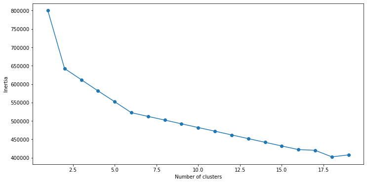

```python
# fitting multiple k-means algorithms and storing the values in an empty list
SSE = []
for cluster in range(1,20):
    kmeans = KMeans(n_jobs = -1, n_clusters = cluster, init='k-means++')
    kmeans.fit(data_scaled)
    SSE.append(kmeans.inertia_)

# converting the results into a dataframe and plotting them
frame = pd.DataFrame({'Cluster':range(1,20), 'SSE':SSE})
plt.figure(figsize=(12,6))
plt.plot(frame['Cluster'], frame['SSE'], marker='o')
plt.xlabel('Number of clusters')
plt.ylabel('Inertia')
```

Let's choose the k value as 6 in our case.

```python
# k means using 6 clusters and k-means++ initialization
kmeans = KMeans(n_jobs = -1, n_clusters = 6, init='k-means++')
kmeans.fit(data_scaled)
pred = kmeans.predict(data_scaled)
```

We can look at the distribution through clusters.

```python
frame = data_scaled.copy()
frame['cluster'] = pred
frame['cluster'].value_counts()
```

```
3    6712
2    6703
0    6671
4    6660
5    6654
1    6600
Name: cluster, dtype: int64
```

We can visualize the result by scatter plot. Let's see how k-means clustering works with k=6 for the age and total bill features of our dataset.

```python
# k means
data_scaled2=data_scaled.copy()
data_scaled2['cluster'] = kmeans.fit_predict(data_scaled2[['age', 'tot_bill']])
# get centroids
centroids = kmeans.cluster_centers_
cen_x = [i[0] for i in centroids]
cen_y = [i[1] for i in centroids]
## add to df
data_scaled2['cen_x'] = data_scaled2.cluster.map({0:cen_x[0], 1:cen_x[1], 2:cen_x[2],3:cen_x[3], 4:cen_x[4], 5:cen_x[5]})
data_scaled2['cen_y'] = data_scaled2.cluster.map({0:cen_y[0], 1:cen_y[1], 2:cen_y[2],3:cen_y[3], 4:cen_y[4], 5:cen_y[5]})
# define and map colors
colors = ['#DF2020', '#81DF20', '#2095DF','#FFFF66','#000066','#996633']
data_scaled2['c'] = data_scaled2.cluster.map({0:colors[0], 1:colors[1], 2:colors[2],3:colors[3], 4:colors[4], 5:colors[5]})
```

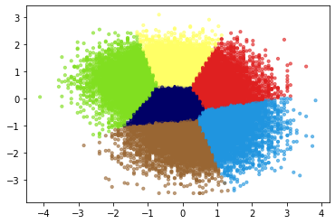

```python
plt.scatter(data_scaled2.age, data_scaled2.tot_bill, c=data_scaled2.c, alpha = 0.6, s=10)
```

At the top figure,we can observe all 6 clusters clearly for total bill and age features.

### Hierarchical Clustering

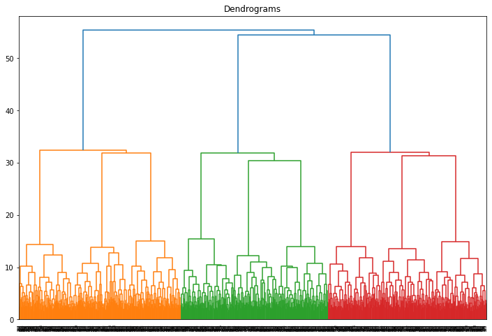

```python
#Visualize the dendogram for deciding the number of clusters for this problem
X = data_scaled.iloc[0:1000, :].values
plt.figure(figsize=(12, 8))
plt.title("Dendrograms")
dend = shc.dendrogram(shc.linkage(X, method='ward'))
```

We can observe that the vertical line with maximum distance occurs for cluster sizes 3 and 9. We can visualize this by selecting thereshold of 50 and 25 and cut the dendogram according to these values:

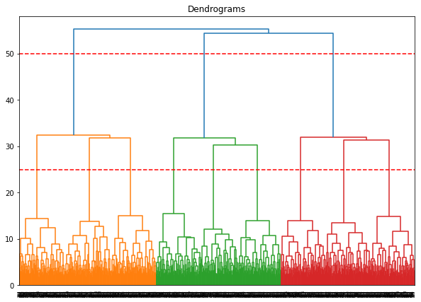

```python
plt.figure(figsize=(10, 7))
plt.title("Dendrograms")
dend = shc.dendrogram(shc.linkage(X, method='ward'))
plt.axhline(y=50, color='r', linestyle='--')
plt.axhline(y=25, color='r', linestyle='--')
```

As we can see from the above red dashed lines, there is strong possiblity that cluster size of 3 and 9 wil give us better calssification results than other cluster sizes. As cluster size 3 seems larger in vertical than cluster size of 9, we will choose the cluster size as 3 fro agglomerative clustering.

```python
#Define Aggloremative Clustering with size 3, euclidean distance and ward linkage methods
cluster = AgglomerativeClustering(n_clusters=3, affinity='euclidean', linkage='ward')
cluster.fit(data_scaled)
cluster.labels_
```

```
array([1, 2, 1, ..., 0, 0, 0], dtype=int64)
```

We can visualize the results as can be seen in the below ( We can observe cluster label for each customer in the dataset)

```python
dfhiear=df.copy()
dfhiear['cluster_'] = cluster.labels_
dfhiear.head()
```

|  | gender | age | home_owner | num_cont | tot_bill | tot_call | tot_bal | tot_bytes | tot_air | num_out | ... | google_air | yahoo_bytes | yahoo_air | marrital_divorced | marrital_married | marrital_single | fortune_Affluent | fortune_LMI | fortune_Mass | cluster_ |
| --- | --- | --- | --- | --- | --- | --- | --- | --- | --- | --- | --- | --- | --- | --- | --- | --- | --- | --- | --- | --- | --- |
| 0 | 1 | 49 | 0 | 0 | 134.130817 | 53 | 4973.07 | 931.28 | 3046.90 | 194 | ... | 1270.23 | 194.04 | 710.45 | 1 | 0 | 0 | 0 | 0 | 1 | 1 |
| 1 | 1 | 33 | 0 | 1 | 121.247165 | 68 | 4528.01 | 580.62 | 3549.74 | 331 | ... | 1484.64 | 32.14 | 823.42 | 1 | 0 | 0 | 0 | 1 | 0 | 2 |
| 2 | 0 | 38 | 0 | 1 | 164.144198 | 38 | 5565.09 | 754.07 | 2996.59 | 139 | ... | 764.69 | 182.07 | 718.69 | 1 | 0 | 0 | 1 | 0 | 0 | 1 |
| 3 | 0 | 26 | 1 | 1 | 177.394137 | 80 | 5370.00 | 384.81 | 2443.78 | 98 | ... | 721.44 | 145.09 | 742.61 | 0 | 1 | 0 | 1 | 0 | 0 | 1 |
| 4 | 1 | 55 | 0 | 2 | 155.183919 | 50 | 5101.25 | 15.30 | 2576.98 | 294 | ... | 774.92 | 15.30 | 710.88 | 0 | 0 | 1 | 1 | 0 | 0 | 1 |

5 rows × 21 columns

[output not shown]

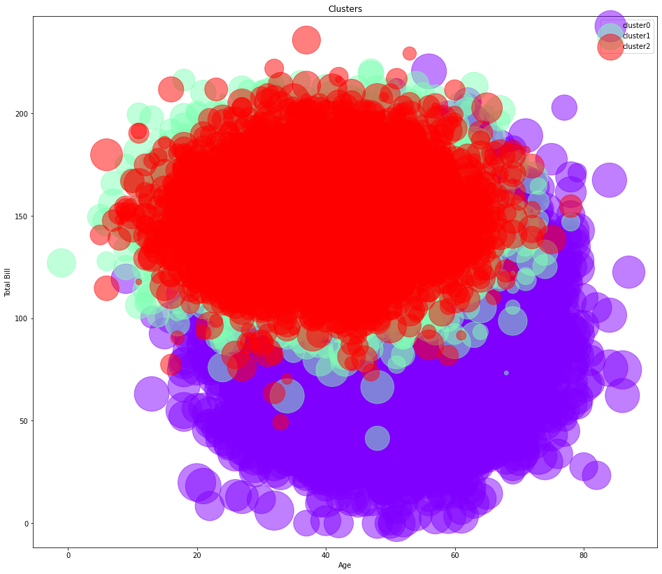

```python
n_clusters = max(cluster.labels_)+1
colors = cm.rainbow(np.linspace(0, 1, n_clusters))
cluster_labels = list(range(0, n_clusters))

# Create a figure of size 6 inches by 4 inches.
plt.figure(figsize=(16,14))

for color, label in zip(colors, cluster_labels):
    subset = dfhiear[dfhiear.cluster_ == label]
    plt.scatter(subset.age, subset.tot_bill, s= subset.tot_bytes, c=color, label='cluster'+str(label),alpha=0.5)


plt.legend()
plt.title('Clusters')
plt.xlabel('Age')
plt.ylabel('Total Bill')
```

As an example, we can plot the behaviour of clusters in 2D dimensions and we selected age and total bill features for observing the clusters. These are two of the crucial features in our dataset. Cluster 0 seems as the most distinguisable one among the clusters. Cluster 1 and 2 have very similar properties in age and total bill as can be seen from red and green points.

```python
agg_customer= dfhiear.groupby(['cluster_'])['gender','age','home_owner','tot_bill','tot_bytes'].mean()
agg_customer
```

| cluster_ | gender | age | home_owner | tot_bill | tot_bytes |
| --- | --- | --- | --- | --- | --- |
| 0 | 0.502459 | 49.481028 | 0.800994 | 99.844177 | 2000.135082 |
| 1 | 0.501343 | 39.692750 | 0.398627 | 149.857783 | 1014.966125 |
| 2 | 0.497001 | 39.454873 | 0.404348 | 150.100832 | 1006.995682 |

Let's also define aggloremative model with 9 clusters and observe the results.

```python
#Define Aggloremative Clustering with size 9, euclidean distance and ward linkage methods
cluster = AgglomerativeClustering(n_clusters=9, affinity='euclidean', linkage='ward')
cluster.fit(data_scaled)
cluster.labels_
```

```
array([6, 2, 6, ..., 4, 8, 1], dtype=int64)
```

```python
dfhiear['cluster_'] = cluster.labels_
dfhiear.head()
```

|  | gender | age | home_owner | num_cont | tot_bill | tot_call | tot_bal | tot_bytes | tot_air | num_out | ... | google_air | yahoo_bytes | yahoo_air | marrital_divorced | marrital_married | marrital_single | fortune_Affluent | fortune_LMI | fortune_Mass | cluster_ |
| --- | --- | --- | --- | --- | --- | --- | --- | --- | --- | --- | --- | --- | --- | --- | --- | --- | --- | --- | --- | --- | --- |
| 0 | 1 | 49 | 0 | 0 | 134.130817 | 53 | 4973.07 | 931.28 | 3046.90 | 194 | ... | 1270.23 | 194.04 | 710.45 | 1 | 0 | 0 | 0 | 0 | 1 | 6 |
| 1 | 1 | 33 | 0 | 1 | 121.247165 | 68 | 4528.01 | 580.62 | 3549.74 | 331 | ... | 1484.64 | 32.14 | 823.42 | 1 | 0 | 0 | 0 | 1 | 0 | 2 |
| 2 | 0 | 38 | 0 | 1 | 164.144198 | 38 | 5565.09 | 754.07 | 2996.59 | 139 | ... | 764.69 | 182.07 | 718.69 | 1 | 0 | 0 | 1 | 0 | 0 | 6 |
| 3 | 0 | 26 | 1 | 1 | 177.394137 | 80 | 5370.00 | 384.81 | 2443.78 | 98 | ... | 721.44 | 145.09 | 742.61 | 0 | 1 | 0 | 1 | 0 | 0 | 5 |
| 4 | 1 | 55 | 0 | 2 | 155.183919 | 50 | 5101.25 | 15.30 | 2576.98 | 294 | ... | 774.92 | 15.30 | 710.88 | 0 | 0 | 1 | 1 | 0 | 0 | 5 |

5 rows × 21 columns

[output not shown]

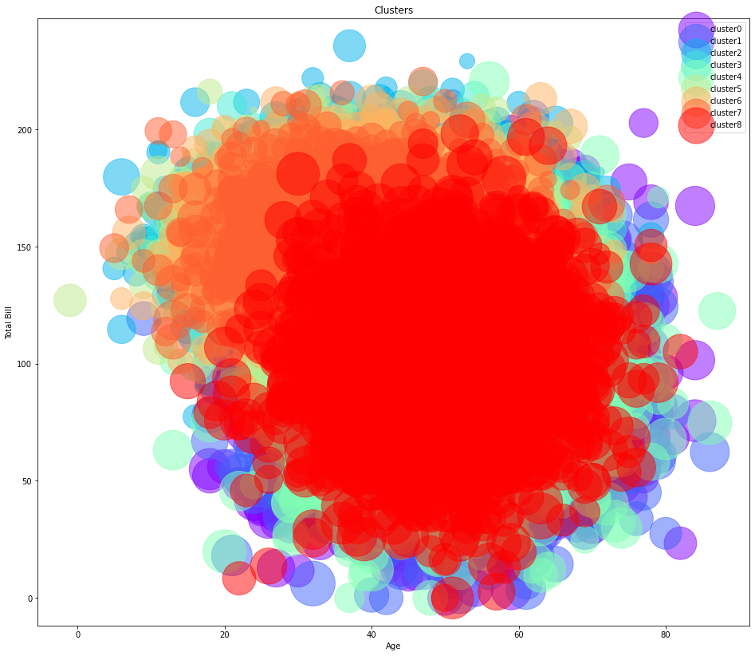

```python
n_clusters = max(cluster.labels_)+1
colors = cm.rainbow(np.linspace(0, 1, n_clusters))
cluster_labels = list(range(0, n_clusters))

# Create a figure of size 6 inches by 4 inches.
plt.figure(figsize=(16,14))

for color, label in zip(colors, cluster_labels):
    subset = dfhiear[dfhiear.cluster_ == label]
    plt.scatter(subset.age, subset.tot_bill, s= subset.tot_bytes, c=color, label='cluster'+str(label),alpha=0.5)


plt.legend()
plt.title('Clusters')
plt.xlabel('Age')
plt.ylabel('Total Bill')
```

We can say that 9 clusters are really hard to distinguish for these two variables and we do not have clear distinguhisble cluster such as cluster 0 when cluster size is 3.

```python
agg_customer= dfhiear.groupby(['cluster_'])['gender','age','home_owner','tot_bill','tot_bytes'].mean()
agg_customer
```

| cluster_ | gender | age | home_owner | tot_bill | tot_bytes |
| --- | --- | --- | --- | --- | --- |
| 0 | 0.499017 | 49.555892 | 0.805324 | 99.693253 | 2001.824526 |
| 1 | 0.500605 | 49.457527 | 0.794287 | 99.829503 | 1998.128959 |
| 2 | 0.497001 | 39.454873 | 0.404348 | 150.100832 | 1006.995682 |
| 3 | 0.507042 | 40.207746 | 0.393926 | 149.698252 | 1002.329591 |
| 4 | 0.508685 | 49.441462 | 0.799233 | 100.180754 | 2001.224058 |
| 5 | 0.501119 | 39.678380 | 0.404432 | 149.849176 | 1025.398679 |
| 6 | 0.501592 | 39.556389 | 0.397681 | 149.899664 | 1013.541878 |
| 7 | 0.495591 | 39.469577 | 0.393739 | 149.953335 | 1009.834462 |
| 8 | 0.505742 | 49.408569 | 0.811396 | 99.668732 | 1998.931974 |

It can be said that gender feature is not a unique feature for defining clusters. However, other features seems like having uniqueness in their values for representing the associated cluster.

### Association Rules with Retail Transaction Data

```python
#Import the dataset
df2= pd.read_excel(r"C:\Users\deniz\Dropbox\My PC (Duygu)\Desktop\BigdataHW7\Retail_Transaction_Example.xlsx")
```

```python
df2.head()
```

|  | CustomerID | StockCode | Description | InvoiceDate |
| --- | --- | --- | --- | --- |
| 0 | 17850.0 | 85123A | WHITE HANGING HEART T-LIGHT HOLDER | 2010-12-01 08:26:00 |
| 1 | 17850.0 | 71053 | WHITE METAL LANTERN | 2010-12-01 08:26:00 |
| 2 | 17850.0 | 84406B | CREAM CUPID HEARTS COAT HANGER | 2010-12-01 08:26:00 |
| 3 | 17850.0 | 84029G | KNITTED UNION FLAG HOT WATER BOTTLE | 2010-12-01 08:26:00 |
| 4 | 17850.0 | 84029E | RED WOOLLY HOTTIE WHITE HEART. | 2010-12-01 08:26:00 |

We only care about the customer ID and the description or stock code for association rule observation. Since we want to get meaningful insight from the data, description makes more sense than the stock code.

We need to remove some of the unncessary spaces in the description column for products.

```python
df2['Description'] = df2['Description'].str.strip()
```

```python
#Define quantity column for each purchase and set it to 1 as each purchase represents a number of sales = 1
df2['Quantity']=1
```

We need to create a *basket* for observing which customer spend which product and how many of those products has been bought by each user.

```python
basket = (df2
          .groupby(['CustomerID', 'Description'])['Quantity']
          .sum().unstack().reset_index().fillna(0)
          .set_index('CustomerID'))
```

```python
basket.head()
```

| Description CustomerID | MEDIUM CERAMIC TOP STORAGE JAR | 3D DOG PICTURE PLAYING CARDS | 3D SHEET OF CAT STICKERS | 3D SHEET OF DOG STICKERS | 60 TEATIME FAIRY CAKE CASES | 72 SWEETHEART FAIRY CAKE CASES | AIRLINE BAG VINTAGE JET SET BROWN | AIRLINE BAG VINTAGE JET SET RED | AIRLINE BAG VINTAGE JET SET WHITE | AIRLINE BAG VINTAGE TOKYO 78 | ... | S/2 BEACH HUT TREASURE CHESTS | PURPLE FRANGIPANI HAIRCLIP | GOLD PRINT PAPER BAG | LILAC FEATHERS CURTAIN | SET/3 TALL GLASS CANDLE HOLDER PINK | FLOWER SHOP DESIGN MUG | CAPIZ CHANDELIER | BLUE NEW BAROQUE FLOCK CANDLESTICK | CAT WITH SUNGLASSES BLANK CARD | SCALLOP SHELL SOAP DISH |
| --- | --- | --- | --- | --- | --- | --- | --- | --- | --- | --- | --- | --- | --- | --- | --- | --- | --- | --- | --- | --- | --- |
| 12346.0 | 2.0 | 0.0 | 0.0 | 0.0 | 0.0 | 0.0 | 0.0 | 0.0 | 0.0 | 0.0 | ... | 0.0 | 0.0 | 0.0 | 0.0 | 0.0 | 0.0 | 0.0 | 0.0 | 0.0 | 0.0 |
| 12347.0 | 0.0 | 5.0 | 1.0 | 1.0 | 3.0 | 3.0 | 6.0 | 3.0 | 3.0 | 4.0 | ... | 0.0 | 0.0 | 0.0 | 0.0 | 0.0 | 0.0 | 0.0 | 0.0 | 0.0 | 0.0 |
| 12348.0 | 0.0 | 0.0 | 0.0 | 0.0 | 2.0 | 1.0 | 0.0 | 0.0 | 0.0 | 0.0 | ... | 0.0 | 0.0 | 0.0 | 0.0 | 0.0 | 0.0 | 0.0 | 0.0 | 0.0 | 0.0 |
| 12349.0 | 0.0 | 0.0 | 0.0 | 0.0 | 0.0 | 0.0 | 0.0 | 0.0 | 0.0 | 0.0 | ... | 0.0 | 0.0 | 0.0 | 0.0 | 0.0 | 0.0 | 0.0 | 0.0 | 0.0 | 0.0 |
| 12350.0 | 0.0 | 0.0 | 0.0 | 0.0 | 0.0 | 0.0 | 0.0 | 0.0 | 0.0 | 0.0 | ... | 0.0 | 0.0 | 0.0 | 0.0 | 0.0 | 0.0 | 0.0 | 0.0 | 0.0 | 0.0 |

5 rows × 3885 columns

```python
#Encode units to one hot encoding as we need that type of input for apriori and association rules
#Each number larger than 0 will be converted to 1, otherwise 0.

def encode_units(x):
    if x <= 0:
        return 0
    if x >= 1:
        return 1

basket_sets = basket.applymap(encode_units)
```

```python
#We can get rid of postage column as it is not meaningful for our purpose.
basket_sets.drop('POSTAGE', inplace=True, axis=1)
```

```python
#Let's select minimum support as 0.07 or 7% for our case.
frequent_itemsets = apriori(basket_sets, min_support=0.07, use_colnames=True)
```

We can set lift condition to 1 or higher as we want to observe most frequent transcations and we can compare the results for subsets that meet this defined condition.

```python
rules = association_rules(frequent_itemsets, metric="lift", min_threshold=1)
rules.head()
```

|  | antecedents | consequents | antecedent support | consequent support | support | confidence | lift | leverage | conviction |
| --- | --- | --- | --- | --- | --- | --- | --- | --- | --- |
| 0 | (ROSES REGENCY TEACUP AND SAUCER) | (GREEN REGENCY TEACUP AND SAUCER) | 0.097667 | 0.089204 | 0.074108 | 0.758782 | 8.506143 | 0.065396 | 3.775824 |
| 1 | (GREEN REGENCY TEACUP AND SAUCER) | (ROSES REGENCY TEACUP AND SAUCER) | 0.089204 | 0.097667 | 0.074108 | 0.830769 | 8.506143 | 0.065396 | 5.331968 |
| 2 | (ROSES REGENCY TEACUP AND SAUCER) | (REGENCY CAKESTAND 3 TIER) | 0.097667 | 0.202882 | 0.074108 | 0.758782 | 3.740018 | 0.054293 | 3.304557 |
| 3 | (REGENCY CAKESTAND 3 TIER) | (ROSES REGENCY TEACUP AND SAUCER) | 0.202882 | 0.097667 | 0.074108 | 0.365276 | 3.740018 | 0.054293 | 1.421615 |
| 4 | (LUNCH BAG RED RETROSPOT) | (LUNCH BAG CARS BLUE) | 0.121683 | 0.110018 | 0.070448 | 0.578947 | 5.262283 | 0.057061 | 2.113707 |

Let's try to observe most frequent relation in the products with high confidence and lift by filtering the output result.

```python
rules[ (rules['lift'] >= 6) &
       (rules['confidence'] >= 0.8) ]
```

|  | antecedents | consequents | antecedent support | consequent support | support | confidence | lift | leverage | conviction |
| --- | --- | --- | --- | --- | --- | --- | --- | --- | --- |
| 1 | (GREEN REGENCY TEACUP AND SAUCER) | (ROSES REGENCY TEACUP AND SAUCER) | 0.089204 | 0.097667 | 0.074108 | 0.830769 | 8.506143 | 0.065396 | 5.331968 |

As we can see from the above result, most strong and correlated relationship occurs between GREEN REGENCY TEACUP AND SAUCER and ROSES REGENCY TEACUP AND SAUCER which are very similar products and we could expect thhis kind of result. So, we could expect from a customer to buy these two products together.

```python
rules[ (rules['lift'] >= 5) &
       (rules['confidence'] >= 0.75) ]
```

|  | antecedents | consequents | antecedent support | consequent support | support | confidence | lift | leverage | conviction |
| --- | --- | --- | --- | --- | --- | --- | --- | --- | --- |
| 0 | (ROSES REGENCY TEACUP AND SAUCER) | (GREEN REGENCY TEACUP AND SAUCER) | 0.097667 | 0.089204 | 0.074108 | 0.758782 | 8.506143 | 0.065396 | 3.775824 |
| 1 | (GREEN REGENCY TEACUP AND SAUCER) | (ROSES REGENCY TEACUP AND SAUCER) | 0.089204 | 0.097667 | 0.074108 | 0.830769 | 8.506143 | 0.065396 | 5.331968 |

```python
rules[ (rules['lift'] >= 4) &
       (rules['confidence'] >= 0.7) ]
```

|  | antecedents | consequents | antecedent support | consequent support | support | confidence | lift | leverage | conviction |
| --- | --- | --- | --- | --- | --- | --- | --- | --- | --- |
| 0 | (ROSES REGENCY TEACUP AND SAUCER) | (GREEN REGENCY TEACUP AND SAUCER) | 0.097667 | 0.089204 | 0.074108 | 0.758782 | 8.506143 | 0.065396 | 3.775824 |
| 1 | (GREEN REGENCY TEACUP AND SAUCER) | (ROSES REGENCY TEACUP AND SAUCER) | 0.089204 | 0.097667 | 0.074108 | 0.830769 | 8.506143 | 0.065396 | 5.331968 |
| 7 | (RED HANGING HEART T-LIGHT HOLDER) | (WHITE HANGING HEART T-LIGHT HOLDER) | 0.088060 | 0.196249 | 0.071363 | 0.810390 | 4.129398 | 0.054081 | 4.238962 |

If we loosen the conditions even more, we can find out a new relationship between (RED HANGING HEART T-LIGHT HOLDER) -> (WHITE HANGING HEART T-LIGHT HOLDER) which tells us that out of all the transactions containing the (RED HANGING HEART T-LIGHT HOLDER) 81% of the transactions are likely to contain (WHITE HANGING HEART T-LIGHT HOLDER) as well. Moreover, lift value of 4.129 shows us that (WHITE HANGING HEART T-LIGHT HOLDER) are 4.129 times more likely to be bought by the customers that buy (RED HANGING HEART T-LIGHT HOLDER), compared it to its default sale scale.

```python
rules[ (rules['lift'] >= 3) &
       (rules['confidence'] >= 0.6) ]
```

|  | antecedents | consequents | antecedent support | consequent support | support | confidence | lift | leverage | conviction |
| --- | --- | --- | --- | --- | --- | --- | --- | --- | --- |
| 0 | (ROSES REGENCY TEACUP AND SAUCER) | (GREEN REGENCY TEACUP AND SAUCER) | 0.097667 | 0.089204 | 0.074108 | 0.758782 | 8.506143 | 0.065396 | 3.775824 |
| 1 | (GREEN REGENCY TEACUP AND SAUCER) | (ROSES REGENCY TEACUP AND SAUCER) | 0.089204 | 0.097667 | 0.074108 | 0.830769 | 8.506143 | 0.065396 | 5.331968 |
| 2 | (ROSES REGENCY TEACUP AND SAUCER) | (REGENCY CAKESTAND 3 TIER) | 0.097667 | 0.202882 | 0.074108 | 0.758782 | 3.740018 | 0.054293 | 3.304557 |
| 5 | (LUNCH BAG CARS BLUE) | (LUNCH BAG RED RETROSPOT) | 0.110018 | 0.121683 | 0.070448 | 0.640333 | 5.262283 | 0.057061 | 2.442025 |
| 7 | (RED HANGING HEART T-LIGHT HOLDER) | (WHITE HANGING HEART T-LIGHT HOLDER) | 0.088060 | 0.196249 | 0.071363 | 0.810390 | 4.129398 | 0.054081 | 4.238962 |
| 9 | (PAPER CHAIN KIT VINTAGE CHRISTMAS) | (PAPER CHAIN KIT 50'S CHRISTMAS) | 0.107502 | 0.140668 | 0.074794 | 0.695745 | 4.946009 | 0.059672 | 2.824378 |
| 10 | (HEART OF WICKER LARGE) | (HEART OF WICKER SMALL) | 0.111391 | 0.131061 | 0.070677 | 0.634497 | 4.841223 | 0.056078 | 2.377377 |

In the above table, we can also observe the transcastions that occurs with lift higher than 3 and confidence higher than 60%.